# Chapter 10: Object-oriented programming

Author

Khiem Nguyen – khiem.nguyen@glasgow.ac.uk

# 1 Why Object-Oriented Programming

## 1.1 Procedure programming vs Object-oriented programming

- Up to now, we’ve been doing a type of programming called **procedure programming**. In procedure programming, the functions and the data those functions operate on are separate entities.
- In **object-oriented programming** (OOP), the focus is on creating program-defined data types that contain both properties and a set of well-defined behaviors.

We won’t discuss why we need Object-Oriented Programming (OOP) in this course:

- We have all learned the importance of OOP in “Introductory Programming 2” and other programming courses.
- Since the 1990s, OOP has been the industry standard.

Instead, I walk you through some job posts in software engineer industry.

## 1.2 The dominance of OOP

- **Why it’s popular**: It mimics how we perceive the world – objects with properties and behaviors.
- **Scalable**: OOP makes it possible to manage large, complex systems where we need to “encapsulate” data to prevent bugs.
- **The industry “lungs”**: If you look at job postings or legacy codebases, OOP is everywhere.

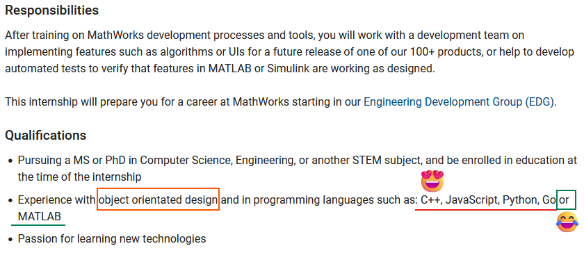

*You don’t need to know MATLAB to find a job in Mathworks*. Instead, you need experience in C++ and OOP.

## 1.3 C++ is highly desired in industry

I asked Gemini about software engineering roles at MathWorks (developing MATLAB you use all the time.)

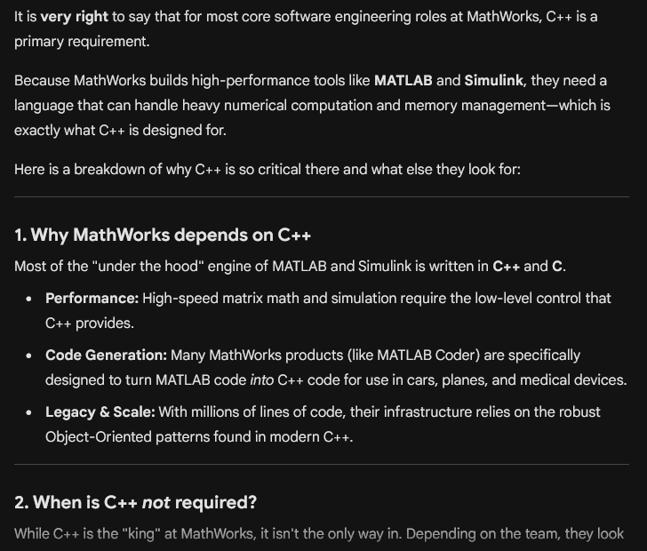

## 1.4 C++ is highly desired in industry: Software architecture at Airbus

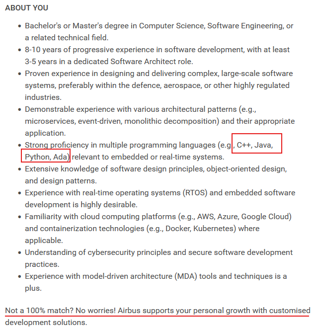

## 1.5 Git Control and OOP are essential skills in industry

Note the requirement of experience with Java. For your record, Java is a pure OOP programming language.

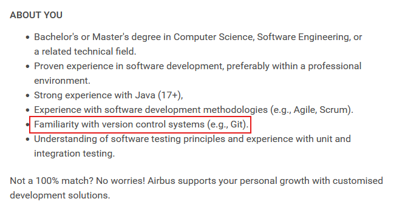

## 1.6 Why OOP: $4$ key pillars of OOP

*I hope this is more than enough to convince you why we need to learn Object-Oriented Programming, especially in C++.*

✎ But that’s a very lazy explanation.

✎ There are four **key pillars in Object-Oriented Programming**

1. **Encapsulation**
2. **Abstraction**
3. **Inheritance**
4. **Polymorphism**

We shall quickly go through each of them, explain what they are and why they are.

## 1.7 Encapsulation

✎ **Encapsulation** is the practice of bundling data (variables) and methods (functions) that operate on that data into a single unit called **class**.

✎ It involves “hiding” the internal state of the object from the outside world to prevent accidental interference.

- **Example 1** Remember what you learned in Python:
  - `ndarray` object in NumPy library
  - `Figure` object is returned when you plot `pyplot.plot(x, y)`
- **Example 2** Think of this code snippet `a = np.array([1, 'two', 3])`:
  - The interpreter tells you the error and *exactly what kind of error you made*.
  - This is because there is *a ton of checking behind the scene*, and *the user does not need to know.*
- **Example 3** Think of registering a student at UoG (python): `Student(name="Bull Shit", age=7)`
  - There must be some behind-the-scene checking, or otherwise mistakes can easily slip through.
  - Inform the user that something is wrong.

## 1.8 Encapsulation

In C++, we use **access specifiers** to achieve this:

✎ `private`: Members are only accessible within the class.

✎ `public`: Members are accessible from outside the class.

- **Example** Think of a **Bank Account**
  - You should not be able to change the `balance` variable directly from outside – otherwise, the bank is F___ed up.
  - You should have to use `deposit()` or `withdraw()` method that checks if the transaction is valid.

## 1.9 Encapsulation

Encapsulation enhances **security**.

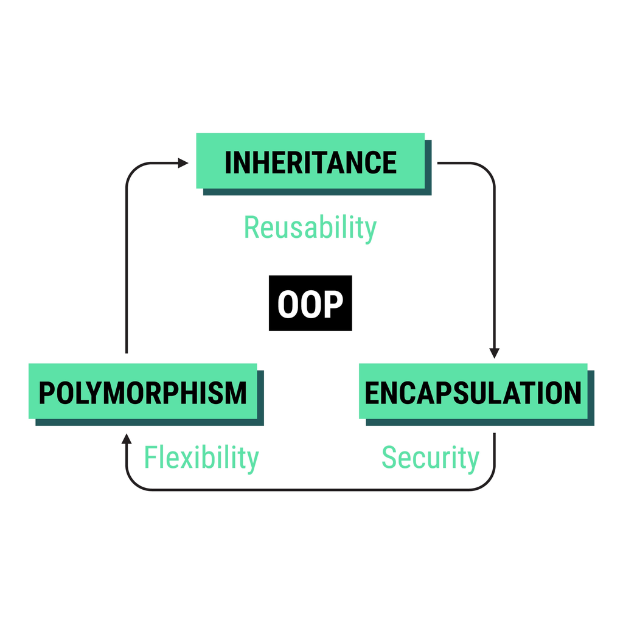

## 1.10 Abstraction

✎ **Abstraction** is about **simplifying** things.

✎ It means showing only the essential features of an object and hiding the complex background details.

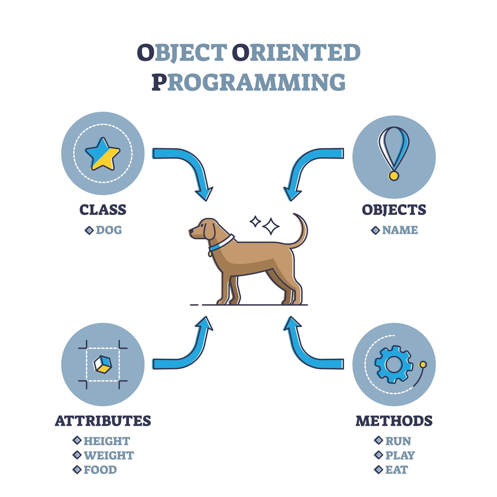

## 1.11 Abstraction

**Why use abstraction**

- **Reduces complexity**: We only deal with a high-level interface (from a user point of view)
- **Easy Maintaince**: We can change the internal “engine” of our code (from a developer point of view) without changing how other people use it.
- **Example** Think of a **Coffee Machine**:
  - only need to know which button to press
  - no need to understand the internal water pressure, size of grind bean, etc.
- **Example** We want to build a graphics app:
  - We want to “*draw*” different shapes, but the ways we draw a Circle and a Square are different.
  - We create an **Abstract Class** called **Shape**. It acts as a blueprint that says: “Anything that is a shape must have a `draw()` method,

    ```cpp
    class Shape {
    public:
        // Pure virtual function makes this an Abstract Class
        virtual void draw() = 0;
    };
    ```

## 1.12 Encapsulation vs Abstraction

- **Encapsulation** is about **protection and data integrity**.
  - **Example** Check if a `battery_level` is negative
  - **Example** Check if a `withdrawl_amount` exeeds a balance
- **Abstraction** is about **interface and simplification**.
  - **Example** Allow user to simply call `set_battery(50)` without having to see the `if (value < 0)` logic hidden inside.

**My own opinion**:

- I try my best to find examples to illustrate these two points.
- Sometimes, I can get confused by myself.
- Some examples can sit at the intersection of both encapsulation & abstraction.
- Don’t worry if you get confused after this 🤨

## 1.13 Inheritance

✎ **Inheritance** allows us to create a new class (**Derived** class or **Child** class) based on existing class (**Base** class or **Parent** class).

✎ The child class “*inherits*” the attributes and behaviors of the parent, which helps us *avoid writing the same code over and over again* ➜ Don’t repeat yourself.

- **Example** An circle is an ellipse.
  - A circle is an ellipse with the same length of two axes.
  - If one can draw an ellipse, there is no point to copy/paste the code to draw a circle.
- **Example** Lecturer, Member of Teaching Office, Technician, Demonstrators are all Employee with names, age, salary, etc.
  - combine all common features and behaviors for all kinds of Employee
  - bundle these features and behaviors into Employee
  - no need to repeat code for each kind of Employee

## 1.14 Polymorphism

**Polymorphism** allows an object to be treated as an instance of its parent class, but still behave according to its own specific type.

- **Example** We can have a list of different shapes and tell them all to `draw()`, and they will each “know” how to draw themselves correctly.
- We shall understand this pillar better when we reach this point.

# 2 `struct` vs `class`

**Importance Note**

*In C++, the difference between a `struct` and a `class` is surprising small from a technical standpoint*, but quite significant from a **stylistic** and **architecture** standpoint.

- Therefore, any example that is implemented using a struct could be implemented using a class, or vice-versa.
- However, from a practical standpoint, we use `struct` and `class` differently.

## 2.1 `struct` vs `class`: Technical difference (defaults)

In C++, a `struct` and a `class` are almost identical, except for the default access level of their members and inheritance. That’s it!

**Default Access Control**

- `struct`: Members (variables and functions) are `public` by default
- `class` : Members are `private` by default

**Default Inheritance**

- `struct`: Inherits `publicly` by default
- `class` : Inherits `privately` by default

We shall study these concepts soon.

## 2.2 `struct` vs `class`: Google C++ style

Technically, you can use `struct` and `class` interchangably. Practically, we use them with different purposes. Google suggests

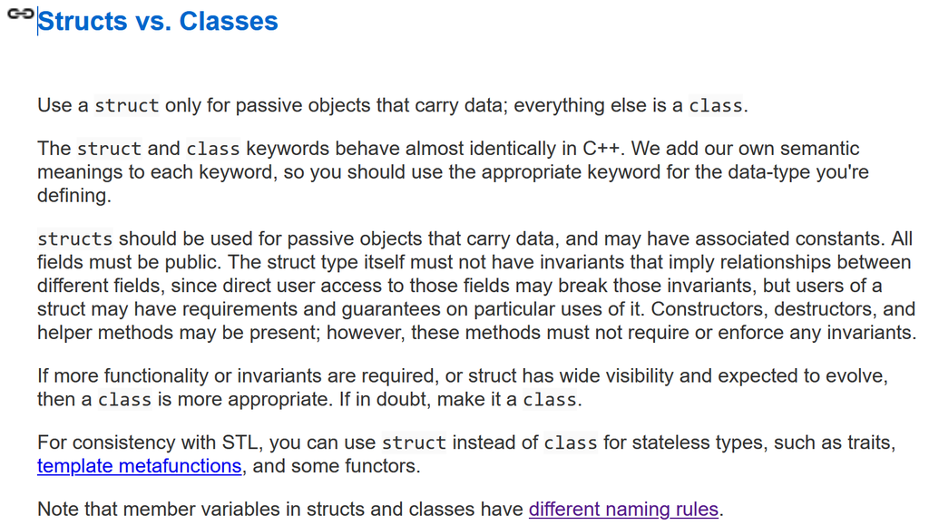

## 2.3 `struct` vs `class`: Google C++ style

**Key points**

- Use a `struct` only for passive objects that carry data; everything else is a `class`.
- The `struct` and `class` keywords behave almost identically in C++. We add our own semantic meanings to each keyword, so you should use the appropriate keyword for the data-type you’re defining.

# 3 Defining a class: Syntax

## 3.1 Defining a class

- A class is a **program-defined** data type. Sometimes, you hear **user-defined** data type.
- Classes are defined similarly to structs: Classes are defined using the `class` keyword, structs using the `struct` keyword.

```cpp
class Employee
{
    int m_id {};            // m_ stands for member, m_id is the member variable
    int m_age {};
    double m_wage {};
}
```

**Naming convention**

✎ The prefix `m_` is used to signify the member variables of a class.

✎ We discuss why member variables of a class are often prefixed with an `m_` in upcoming lesson.

## 3.2 Naming convention: Google style

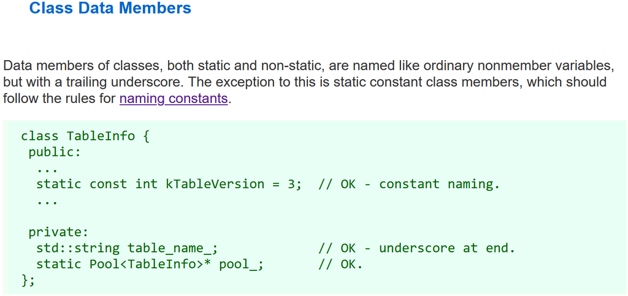

## 3.3 Naming convention: Which to choose

- Several companies and wide industry have adopted the prefix `m_` naming convention.

  ```cpp
  class Employee
  {
      int m_id {};
      int m_age {};
      double m_wage {};
  }
  ```

- Google suggests trailing underscore, such as `id_`, `age_`, and `wage_`

  ```cpp
  class Employee
  {
      int id_ {};
      int age_ {};
      double wage_ {}
  }
  ```

✎ When we use the prefix `m_` convention, the intelliSense will suggest variable names when we type `m_`.

## 3.4 Naming convention: Which to choose … and But

- The prefix `m_` or the suffix `_` help us to avoid **name shadowing** in **class constructors**.
- When you learn more about modern C++ (in our lectures actually), you soon recognize: we don’t even need the above naming conventions.

Conclusion:

- I would prefer not to use the prefix naming convention `m_` in our lectures.
- Saying that, sometimes I mix the convention `m_` in on purpose (or maybe by forgetting).

## 3.5 A `class` can implement a `struct`

By declaring `public` member variables, a `class` behaves just like a `struct`.

Listing 1: A `class` behaves like a `struct` by declaring member variables `public`. Filename=`class_just_like_struct.cpp`

```cpp
#include <iostream>

class Date       // we changed struct to class
{
public:          // and added this line, which is called an access specifier
    int m_day{};        // we can add "m_" prefixes to each of the member
    int m_month{};      // names to avoid shadowing. But this is not really necessary
    int m_year{};       // in modern C++.
};

void print_date(const Date& date)
{
    std::cout << date.m_day << '/' << date.m_month << '/' << date.m_year;
}

int main()
{
    Date date{ 4, 10, 21 };
    print_date(date);

    return 0;
}
```

## 3.6 Most of the C++ standard library is classes

We have already been using class objects, perhaps without knowing it:

- `std::string`
- `std::string_view`
- `std::vector`

In fact, most of the non-aliased types in the standard library are defined as classes!

Classes are really the heart and soul of C++ – they are so foundational that C++ was originally named “C with classes”!

# 4 Member functions and implicit objects

- In this Section, we shall use `struct` to demonstrate the concepts.
- By using `struct`, I can demonstrate that `struct` and `class` are technically almost the same.

## 4.1 Member functions

- In addition to having member variables, `class` types (which include `struct`, `class`, `union`) can have their own functions.
- Functions that belong to a class type are called **member functions**.
- Functions that are not member functions are called **non-member functions**.

## 4.2 A non-member function example

Let us look at the following example:

Listing 2: An example of non-member function. Filename=`non_member_function_example.cpp`

```cpp
#include <iostream>

struct Date
{
    // here are our member variables
    int year {};
    int month {};
    int day {};
};

void print(const Date& date)
{
    // member variables accessed using member selection operator (.)
    std::cout << date.year << '/' << date.month << '/' << date.day;
}

int main()
{
    Date today { 2026, 02, 27 }; // aggregate initialize our struct

    today.day = 16; // member variables accessed using member selection operator (.)
    print(today);   // non-member function accessed using normal calling convention

    return 0;
}
```

## 4.3 A member function example

In this lesson, we’ll use structs to show examples of member functions – but everything we show here applies equally well to classes.

Listing 3: An example of member function. Filename=`member_function_example.cpp`

```cpp
// Member function version
#include <iostream>

struct Date
{
    int year {};        // We don't use m_ here for struct. Generally, we don't
    int month {};       // want to write constructor for struct. Then, there is
    int day {};         // NO SHADOWING of variables (we talk later in `class`)

    void print() // defines a member function named print
    {
        std::cout << year << '/' << month << '/' << day;
    }
};

int main()
{
    Date today { 2026, 02, 26 }; // aggregate initialize our struct
    today.day = 16; // member variables accessed using member selection operator (.)
    today.print();  // member functions also accessed using member selection operator (.)
    std::cout << '\n';
    return 0;
}
```

## 4.4 Calling member functions and the implicit object

- In the non-member example, we call

  ```cpp
  print(today)
  ```

- In the member example, we call

  ```cpp
  today.print()
  ```

- In the member function case, we don’t pass `today` as an argument.
- The object is **implicitly** passed to the member function.
- The object that member function is called on is called **implicit object**

## 4.5 Assessing members inside a member function uses the implicit object

✎ In the non-member example, we define

```cpp
// non-member version of print
void print(const Date& date)
{
    // member variables accessed using member selection operator (.)
    std::cout << date.year << '/' << date.month << '/' << date.day;
}
```

✎ In the member example, we define

```cpp
void print() // defines a member function named print()
{
    std::cout << year << '/' << month << '/' << day;
}
```

- We access the members as `year`, `month`, and `day`.
- Any member identifier that is not prefixed with the member selection operator (`.`) is associated with the implicit object.
- `year`, `month`, and `day` (which are not prefixed) evaluate to the values of `today.year`, `today.month`, and `today.day` respectively.

## 4.6 A comparison to OOP in Python

```python
class Date:
  def __init__(self, year=2026, month=2, date=28): # we learn constructor in C++ soon
    self.year = year
    self.month = month
    self.date = date
  def print(self):
    print(f"{self.year}/{self.month}/{self.date}")  # we don't have self. in C++

# Use this class in global scope
today = Date(2026,2,26) # when this lecture first took place
today.print()
# How about this: I know that many of you did not learn it in
# Introductory Programming 2. I am cooler :D
Date.print(today) # exposes the implicit object in the statement today.print()
```

```
2026/2/26
2026/2/26
```

## 4.7 A comparison to OOP in Python: Repeat last slide

```python
class Date:
  # blah blah

  def print(self):
    print(f"{self.year}/{self.month}/{self.date}")  # we don't have self. in C++
# Use this class in global scope
today = Date(2026,2,26) # when this lecture first took place
today.print()
Date.print(today)   # this exposes the implicit object in the statement today.print()
```

- What we have just learned in C++ looks different from Python you know. We don’t have `self`: `self.year`, `self.month`, `self.day`.
- We shall learn an equivalence of `self` of Python in C++.
- Statement `Date.print(today)` exposes the implicit object in statement `today.print()`

## 4.8 A comparison to OOP in Python: But Python is not as serious as C++

```python
class Date:
  def __init__(self, year=2026, month=2, date=28): # we learn constructor in C++ soon
    self.year = year
    self.month = month
    self.date = date

  def print(self):
    print(f"{self.year}/{self.month}/{self.date}")  # we don't have self. in C++
# Use this class in global scope
today = Date(2026,2,26) # when this lecture first took place
my_name = "khiem"
Date.print(my_name) # SYNTAX Correct, but run time error. my_name.year does not exist
```

```
---------------------------------------------------------------------------
AttributeError                            Traceback (most recent call last)
Cell In[20], line 12
     10 today = Date(2026,2,26) # when this lecture first took place
     11 my_name = "khiem"
---> 12 Date.print(my_name) # SYNTAX Correct, but run time error. my_name.year does not exist

Cell In[20], line 8, in Date.print(self)
      7 def print(self):
----> 8   print(f"{self.year}/{self.month}/{self.date}")

AttributeError: 'str' object has no attribute 'year'
```

## 4.9 A comparison to OOP in Python: But Python is not as serious as C++

```python
class Date:
  def __init__(self, year=2026, month=2, date=28): # we learn constructor in C++ soon
    self.year, self.month, self.date = year, month, date
  def print(self):
    print(f"{self.year}/{self.month}/{self.date}")  # we don't have self. in C++

class Foo:
  def __init__(self):
    self.year, self.month, self.date = "one", "two", 3
# Use this class in global scope
today = Date(2026,2,26) # when this lecture first took place
foo_object = Foo()

# SYNTAX correct, and Code run fine too. But it is just nonsense
Date.print(foo_object)
```

```
one/two/3
```

## 4.10 Member functions can be overloaded

✎ Just like non-member functions, member functions can be overloaded.

Listing 4: Member functions can be overloaded. Filename=`overload_member_functions.cpp`

```cpp
#include <iostream>
#include <string_view>

struct Date
{
    int year {}; int month {}; int day {};  // Do not write like this! Save space for slide
    void print() {
        std::cout << year << '/' << month << '/' << day;
    }
    void print(std::string_view prefix) {
        std::cout << prefix << year << '/' << month << '/' << day;
    }
};

int main()
{
    Date today { 2020, 10, 14 };
    today.print(); // calls Date::print()
    std::cout << '\n';
    today.print("The date is: "); // calls Date::print(std::string_view)
    std::cout << '\n';

    return 0;
}
```

## 4.11 Structs and member functions: A bit of history

- In C, structs only have data members, not member functions.
- While designing classes in C++, Bjarne Stroustrup considered whether structs (which were inherited from C) should be granted the ability to have member functions.
- Upon consideration, he determined that they should.
- In modern C++, it is fine for structs to have member functions.

✎ Both structs and classes are called **class type**

# 5 Const class objects and const member functions

✎ Again, we shall use `struct` for examples in this section.

## 5.1 Const variables: A quick revisit

- We learn: All const variables must be initialized at time of creation

  ```cpp
  const int x { 42 };
  const double double z {};    // initialze to zero.
  ```

- Similarly, class type objects can be made const using `const` keyword

  ```cpp
  struct Date
  {
      int year {};
      int month {};
      int day {};
  };
  int main()
  {
      // const class type object
      const Date today { 2020, 10, 14 };
      return 0;
  }
  ```

## 5.2 Modifying the data members of const objects is disallowed

✎ Any attempt to modify the data members of the object is disallowed.

Listing 5: Modifying the data members of const objects is disallowed. Filename=`modify_members_of_const_objects.cpp`

```cpp
struct Date
{
    int year {}, month {}, day {};

    void increment_day() {
        ++day;
    }
};

int main()
{
    const Date today { 2020, 10, 14 }; // const
    today.day += 1;        // compile error: can't modify member of const object
    today.increment_day();  // compile error: can't call member function that modifies member of const object

    return 0;
}
```

➥ Show the code with uncommented code. IntelliSense picked up the error before compilation.

## 5.3 Const objects may not call non-const member functions

✎ You may be surprised that the following code causes compilation error.

Listing 6: const object calling the non-const member functions will create compilation error.

```cpp
#include <iostream>

struct Date
{
    int year {}, month {}, day {};
    void print()     {
        std::cout << year << '/' << month << '/' << day;
    }
};

int main()
{
    const Date today { 2020, 10, 14 }; // const
    // today.print();  // compile error: can't call non-const member function
    return 0;
}
```

## 5.4 Const member functions

✎ To address the above issue, we make `print()` a const member function.

✎ A **const member function** is a member function that guarantees it will not modify the object or call any non-const member functions (as they may modify the object)

Listing 7: const member function can be called by const objects. Filename=`const_member_functions.cpp`

```cpp
#include <iostream>

struct Date
{
    int year {}, month {}, day {};
    void print() const // now a const member function
    {
        std::cout << year << '/' << month << '/' << day;
        double another_year {42};
        another_year += 1;
    }
};

int main()
{
    const Date today { 2020, 10, 14 }; // const
    today.print();  // ok: const object can call const member function

    return 0;
}
```

## 5.5 Const member functions

✎ **Not a surprise**: A const member function that attempts to change a data member or call a non-const member function will cause a compiler error to occur.

Listing 8: A const member function cannot change data members. Filename=`const_member_functions_change_data_members.cpp`

```cpp
struct Date
{
    int year {}, month {}, day {};

    void increment_day(int val) const // made const
    {
        // day += val; // compile error: const function can't modify member
    }
};

int main()
{
    const Date today { 2020, 10, 14 }; // const

    today.increment_day(4);

    return 0;
}
```

## 5.6 Const member functions can be called on non-const objects

✎ **Not a surprise** (again): Const member functions may also be called on non-const objects.

- We promise the compiler *const member functions won’t change the data members.*
- Indeed, non-const objects calling const member functions cannot break such promise.

## 5.7 Const member functions can be called on non-const objects

Listing 9: A non-const object can call const member functions because it cannot break the promise of constant-ness. Filename=`nonconst_objects_call_const_mem_functions.cpp`

```cpp
#include <iostream>

struct Date
{
    int year {}, month {}, day {};
    void print() const {// const
        std::cout << year << '/' << month << '/' << day;
    }
};
int main()
{
    Date today { 2020, 10, 14 }; // non-const
    today.print();  // ok: can call const member function on non-const object

    return 0;
}
```

## 5.8 Const member functions can be called on non-const objects

A member function that does not (and will not ever) modify the state of the object should be made const, so that it can be called on both const and non-const objects.

## 5.9 Wait a minute: What a mess

- How am I supposed to remember all the const-ness thingys.
- I am not even Tony Stark or Spider Man.

So, I asked Gemini:

*There are too many things to remember about making function const and making reference const in writing C++ code to deal with const objects. Can you please give me one or two single golden rule so that I remember what I should do?*

Gemini answers me (I shortened it a bit):

If you are working with **structs** or **classes**, here are the two golden rules that will cover 95% of your needs.

✎ **Rule 1** The “Read-Only” Rule (For Functions)

If a function does not change the object’s data, mark it `const` at the end.

Think of it as a promise to the compiler.

✎ **Rule 2** The “Efficient Pass” Rule (For Parameters)

Always pass objects by `const &` (const reference) unless they are tiny or we need to modify its value.

➥ Let us combine both rules into one example

## 5.10 Const objects via pass by const reference

**Recap:**

- Passing a class type argument by value causes a copy of the class to be made – which is slow.
- **Passing by reference avoids making a copy.**

**Note**

- Note that modifying the argument’s value is not the key point. It is a side effect.
- If we add `const` qualifier, we cannot modify the arguments’ value.
- Of course, *we wish to modify the argument’s value in reasonable cases.*

**Another Note**

- Instantiating const local variables is one way to create const objects
- Another common way to get a const object is *by passing an object to a function by const reference. But, this only holds from the perspective of that function.*

## 5.11 Const objects via pass by const reference

**Question** What’s wrong with the following code?

Listing 10: Passing an object by const reference make the object const in the perspective of the function. Filename=`const_objects_via_pass_by_const_ref_01.cpp`

```cpp
#include <iostream>

struct Date
{
    int year {}, month {}, day {};
    void print() {  // non-const
        std::cout << year << '/' << month << '/' << day;
    }
};

void do_something(const Date& date) {
    date.print();
}

int main()
{
    Date today { 2020, 10, 14 }; // non-const
    today.print();
    do_something(today);

    return 0;
}
```

➥ Compile the file and show the code in VSCode.

## 5.12 Const objects via pass by const reference

Yup, the fix is simple: make `print()` const

Listing 11: Fix the above code listing by making `print()` const. Filename=`const_objects_via_pass_by_const_ref_01.cpp`

```cpp
#include <iostream>

struct Date
{
    int year {}, month {}, day {};
    void print() const {  // non-const
        std::cout << year << '/' << month << '/' << day;
    }
};

void do_something(const Date& date)
{
    date.print();
}

int main()
{
    Date today { 2020, 10, 14 }; // non-const
    today.print();

    do_something(today);

    return 0;
}
```